# Solutions to Problems in (Re)doing Bayesian Data Analysis

R Pruim

2019-04-26

# Part B

## Chapter 16

1. Using the 30-year-olds in the `NHANES` data set (in the NHANES package), fit a model that compares the mean height for men and women (allowing for different standard deviations). Then and answer the following questions about your model.
   1. Explain your choice of priors.
   2. Does this sample provide enough evidence to conclude that men are taller (on average)?
   3. Does this sample provide enough evidence to conclude that the standard deviation of height differs between men and women?

   ```r
   Thirty <- NHANES::NHANES %>% filter(Age == 30)
   df_stats(Height ~ Gender, data = Thirty)
   ```

   ```
   ##   Gender   min    Q1 median      Q3   max     mean       sd  n missing
   ## 1 female 152.4 159.0 163.90 168.600 181.3 164.2658 6.731440 73       3
   ## 2   male 153.0 171.7 176.15 181.075 186.8 175.6744 7.082239 90       0
   ```

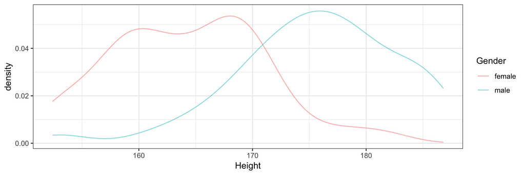

   ```r
   gf_dens( ~ Height, color = ~ Gender, data = Thirty, binwidth = 1)
   ```

2. Repeat exercise 1, but compare pulse instead of height.

The previous two questions are similar. Fitting the models in JAGS is not that challenging. The interesting parts of these problems were selecting and justifying the prior and interpreting the posterior.

There is some lattitude regarding how to select a prior. Let’s suppose the likelihood is specified by

$$Y_{i|g} \sim {\sf Norm}(\mu_g, \sigma_g)$$

Then we need priors for $\mu_g$ and $\sigma_g$. (Technically, we need a *joint prior* for $\mu_1$, $\mu_2$, $\sigma_1$ and $\sigma_2$. But if the marginal priors are independent, then specifying the marginal priors determines the joint prior.)

Some important things about selecting the prior:

- A normal prior is a fine choice for $\mu_g$.
- The mean of this normal prior for $\mu_g$ should be near where we believe the mean height of people (in one group) is (prior to using our data).  
  **0 is not a good choice in this situation unless you use a very large $\sigma$** because we don’t expect the mean (for eiether group) to be close to 0.
- It is fine to use the same mean for the priors for both genders. The data will push those apart in the posterior as long as the prior isn’t too narrow.
- The standard deviation/precision of the prior for $\mu_g$ is **not** a measure of variability in the population. It is a measure of your certainty about the mean you are providing to the prior. Your explanation of how you chose the prior for the standard deviation should reflect that you understand this distinction.
- You also need a prior for the standard deviation $\sigma_g$. $\sigma_g$ represents the amount of variability of $y$ (height or pulse) in each gender group. This is the place to encorporate what you know about how large that standard deviation might be.

Note the use of separate standard deviations is not an “assumption that they are different”, but it allows them to be different and so gives us a way to test wether they are the same or different (as you were asked to do in part c).

Don’t forget to do some diagnostics. Some of you made small errors/typos that led to models that were clearly not correct but didn’t notice.

A note on *the* posterior: There is only one posterior (and only one prior, and one likelihood). Typically the posterior is a joint distribution, so we can talk about the marginal distributions of its components. We will often refer to these as the posterior for $\mu$ or the posterior for $\sigma$. It would be more explicit to refer to these as the *marginal* posteriors for these quantities.

When checking whether two parameters are different, look at the posterior distribution for the difference, not the amount of overlap in the two posterior distributions.

If the posterior distribution of a difference straddles 0, this does not allow you to conclude that there is no difference. If you use a ROPE and the entire HDI is contained in the ROPE, then you can conclude there is no practical difference (at least to the degree specified by the probability of your HDI).

3. The typical lifespan of a laboratory rat that eats ad lib is approximately 700 days. When rats are placed on a restricted diet, their longevity can increase, but there is a lot of variability in lifespans across different individual rats. Restricting the diet might not only affect the typical lifespan, but restricting the diet might also affect the variance of the lifespan across rats. We consider data from R. L. Berger, Boos, and Guess (1988), as reported in Hand, Daly, Lunn, McConway, and Ostrowski (1994, data set #242), and which are available as `CalvinBayes::RatLives`.
   1. Run the two-group analysis on the rat longevity data using a t distribution for the response variable. Do the groups appear to differ in their central tendencies and variances? Does the value of the normality parameter suggest that the distribution of lifetimes has heavier tails than a normal distribution?
   2. Did you plot the data before doing part a? It’s a good idea to do that. Create a plot that compares the distributions of rat life for the two groups of rats in the data.
   3. Your plot should have revealed that within each group the data appear to be skewed to the left. That is, within each group, there are many rats that died relatively young, but there are fewer rats who lived especially long. We could try to implement a skewed noise distribution, or we could try to transform the data so they are approximately symmetric within each group after transformation. We will try the latter approach here. To get rid of leftward skew, we need a transformation that expands larger values more than the smaller values. We will try squaring the data. (You an use `mutate()` to add a new variable containing the square of the lifetimes of the rats to the original data or you can take care of this inside the list that you pass to JAGS). Do the groups appear to differ in their central tendencies and variances with this model? What does the value of the normality parameter suggest about the distribution of the transformed lifetimes?
   4. To compare the results of the two models, it is useful to back-transform to the natural scale. Give a 90% posterior HDI for the difference in mean lifetime based on each model. These should both be in units of days.
   5. Did you use ROPEs in any of your answers above? If not, go back and do so. (You will need to decide how wide the ROPE should be and if/how it changes when you apply the transformation.)

The two groups look different, but neither one looks particularly symmetric. (Other types of plots could be used here as well.)

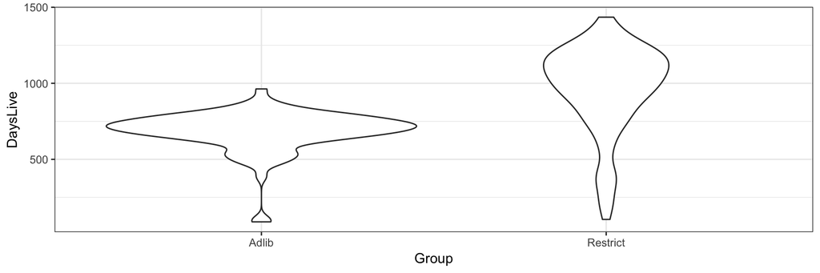

```r
gf_violin(DaysLive ~ Group, data = RatLives)
```

Nevertheless, we will proceed with this model for the moment. Let’s build a generic version of the model in JAGS that we can recycle for other purposes as we go along.

```r
# y ~ g where y is metric and g is 1 or 2

metric_dich_model <- function() {
  for (i in 1:Nobs) {
    y[i] ~ dt(mu[g[i]], 1 / sigma[g[i]]^2, nu[g[i]])
  }
  for (g in 1:2) {
    mu[g]         ~ dnorm(mu_mean, 1 / mu_sd^2)
    sigma[g]      ~ dunif(sigma_lo, sigma_hi)
    nuMinusOne[g] ~ dexp(1 / 29.0)
    nu[g]        <- nuMinusOne[g] + 1
    log10nu[g]   <- log(nu[g]) / log(10)
  }
  delta_mu     <- mu[2] - mu[1]
  delta_sqrtmu <- sqrt(abs(mu[2])) - sqrt(abs(mu[1]))  # for sake of second attempt
  sigma_ratio  <- sigma[2] / sigma[1]
}
```

Now let’s fit the model.

```r
rats_jags <-
  jags(
    model = metric_dich_model,
    parameters.to.save =
      c("mu", "sigma", "delta_mu", "sigma_ratio", "log10nu"),
    data = list(
      Nobs = nrow(RatLives),
      y = RatLives$DaysLive,
      g = as.numeric(factor(RatLives$Group)),
      mu_mean  = 700,      # approximate average life of a rat
      mu_sd    = 300,      # pretty sure mean is between 100 and 1300 (for each group)
      sigma_lo = 60 / 1000,
      sigma_hi = 60 * 1000
    ),
    n.iter = 5000,
    n.burnin = 1000,
    n.chains = 4,
    n.thin = 2,
    DIC = FALSE
  )
```

Let’s take a look a what we have.

```r
rats_jags
```

```
## Inference for Bugs model at "/var/folders/py/txwd26jx5rq83f4nn0f5fmmm0000gn/T//RtmpqhObxc/model1610a59ae5540.txt", fit using jags,
##  4 chains, each with 5000 iterations (first 1000 discarded), n.thin = 2
##  n.sims = 8000 iterations saved
##              mu.vect sd.vect    2.5%     25%      50%      75%    97.5%
## delta_mu     298.101  33.927 229.138 275.299  299.174  321.839  360.356
## log10nu[1]     0.484   0.163   0.199   0.373    0.469    0.581    0.842
## log10nu[2]     0.874   0.404   0.335   0.573    0.771    1.105    1.834
## mu[1]        706.029  10.643 684.321 698.888  706.240  713.307  726.562
## mu[2]       1004.129  32.369 937.931 982.560 1005.769 1026.805 1063.531
## sigma[1]      79.650  11.628  58.556  71.476   79.118   87.317  104.168
## sigma[2]     232.669  36.021 167.582 205.475  231.624  259.367  302.287
## sigma_ratio    2.986   0.653   1.879   2.525    2.925    3.387    4.423
##              Rhat n.eff
## delta_mu    1.001  8000
## log10nu[1]  1.001  5300
## log10nu[2]  1.002  2500
## mu[1]       1.001  8000
## mu[2]       1.001  8000
## sigma[1]    1.001  5600
## sigma[2]    1.001  8000
## sigma_ratio 1.001  8000
##
## For each parameter, n.eff is a crude measure of effective sample size,
## and Rhat is the potential scale reduction factor (at convergence, Rhat=1).
```

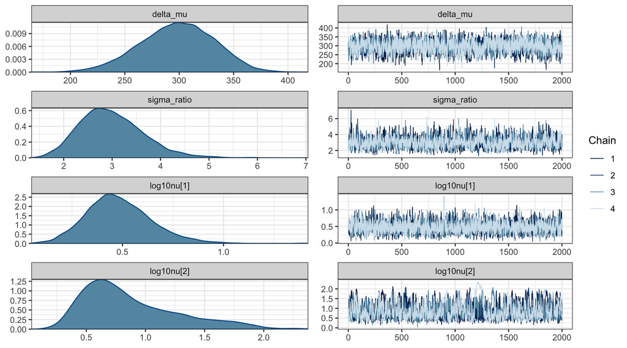

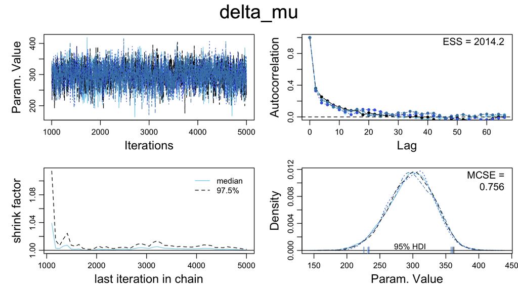

```r
rats_mcmc <- as.mcmc(rats_jags)
mcmc_combo(rats_mcmc, regex_pars = c("delta", "ratio", "log"))
diag_mcmc(rats_mcmc)
```

Convergence looks good, but $\sigma$ and $\nu$ are being inefficiently sampled. (If we were really going to use the model, we would like run longer to boost the effective sample size.)

Suppse we are only interested in differences in average lifetime of at least 60 days, and differences in $\sigma$ of at least 10%.

```r
plot_post(posterior(rats_jags)$delta_mu, ROPE = c(-60, 60), xlab = "delta_mu")
```

```
## $posterior
##           ESS     mean   median     mode
## var1 2070.804 298.1006 299.1735 299.4048
##
## $hdi
##   prob     lo       hi
## 1 0.95 232.52 362.6606
##
## $ROPE
##    lo hi P(< ROPE) P(in ROPE) P(> ROPE)
## 1 -60 60         0          0         1
```

```r
hdi(posterior(rats_jags), regex_pars = "delta_mu")
```

```
##        par     lo       hi prob
## 1 delta_mu 232.52 362.6606 0.95
```

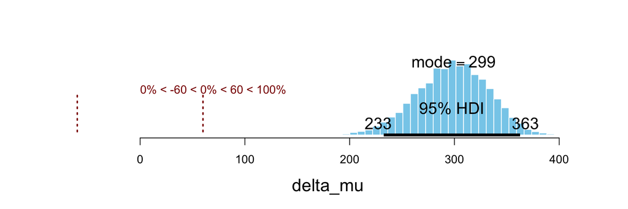

```r
plot_post(posterior(rats_jags)$sigma_ratio, ROPE = c(0.9, 1.1), xlab = "sigma_ratio")
```

```
## $posterior
##           ESS     mean   median     mode
## var1 1831.936 2.986193 2.924575 2.731553
##
## $hdi
##   prob     lo       hi
## 1 0.95 1.7616 4.263581
##
## $ROPE
##    lo  hi P(< ROPE) P(in ROPE) P(> ROPE)
## 1 0.9 1.1         0          0         1
```

```r
hdi(posterior(rats_jags), regex_pars = "sigma_ratio")
```

```
##           par     lo       hi prob
## 1 sigma_ratio 1.7616 4.263581 0.95
```

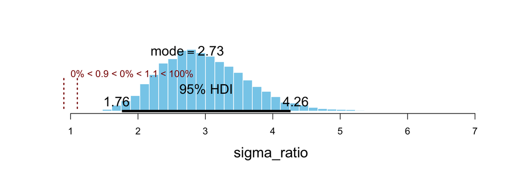

```r
hdi(posterior(rats_jags), regex_pars = "log")
```

```
##         par        lo        hi prob
## 1 log10nu.1 0.1813248 0.8099559 0.95
## 2 log10nu.2 0.2839673 1.7514411 0.95
```

According to this model,

- There is a clear difference in mean longevity, with all of the posterior distribution for the difference in means is well outside a ROPE of $\pm 2$ months (60 days).  
  Indeed, the rats on the restricted diet seem to live 8 months to a year longer on average.
- the standard deviations also appear to be different.
- group 1 (ad lib) seems to have clearly heavier than normal tails.
- group 2 (restricted) may also have heavier tails but the evidence is not as clear (much of the posterior credibility of $log_10(\nu)$ is less than 1.5).

But modeling the distribution of the response as a symmetric (t) distribution doesn’t seem to align with the data. So let’s try squaring the response.

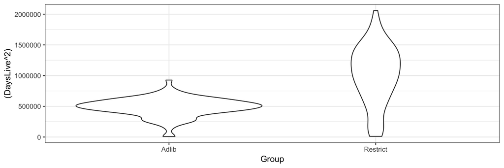

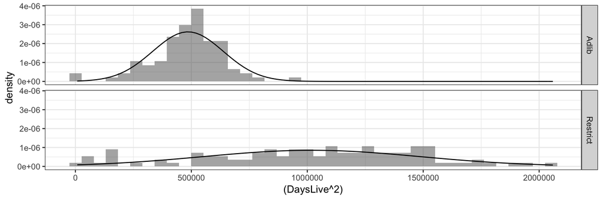

```r
gf_violin((DaysLive^2) ~ Group, data = RatLives)
gf_dhistogram(~ (DaysLive^2) | Group ~ ., data = RatLives, bins = 40) %>%
  gf_fitdistr()
```

The squared lives do appear to be more symmetrically distributed.

Let’s a fit a new model wit the lifetimes squared. Note that the mean of a squared distribuion is not the mean of the original distribution squared:

$$E(X^2) = E(X)^2 + Var(X) \neq E(X)^2$$

```r
rats2_jags <-
  jags(
    model = metric_dich_model,
    parameters.to.save =
      c("mu", "sigma", "delta_mu", "sigma_ratio", "delta_sqrtmu", "log10nu"),
    data = list(
      Nobs = nrow(RatLives),
      y = RatLives$DaysLive^2,
      g = as.numeric(factor(RatLives$Group)),
      mu_mean  = 700^2 + 300^2,
      mu_sd    = (700^2 + 300^2) / 3,  # takes 3 sd's to get to negative values
      sigma_lo = 500 / 1000,
      sigma_hi = 500 * 1000
    ),
    n.iter   = 5000,
    n.burnin = 1000,
    n.chains = 4,
    n.thin   = 2,
    DIC      = FALSE
  )
```

```r
summary(rats2_jags)
```

```
## fit using jags
##  4 chains, each with 5000 iterations (first 1000 discarded), n.thin = 2
##  n.sims = 8000 iterations saved
##                  mu.vect   sd.vect       2.5%        25%         50%
## delta_mu      508736.608 48178.970 415019.324 476095.302  508838.348
## delta_sqrtmu     298.580    25.430    248.680    281.440     298.647
## log10nu[1]         1.030     0.391      0.431      0.727       0.969
## log10nu[2]         1.530     0.310      0.911      1.313       1.541
## mu[1]         492920.082 15987.963 460788.700 482564.279  492914.583
## mu[2]        1001656.690 45406.261 911951.828 971722.640 1001280.963
## sigma[1]      132907.193 17554.461  99642.494 120919.095  133018.534
## sigma[2]      453425.474 26875.799 396808.997 435422.322  455529.199
## sigma_ratio        3.474     0.526      2.621      3.098       3.412
##                      75%       97.5%  Rhat n.eff
## delta_mu      540871.192  603009.022 1.002  2700
## delta_sqrtmu     315.598     347.809 1.002  2800
## log10nu[1]         1.293       1.876 1.001  8000
## log10nu[2]         1.759       2.085 1.002  2700
## mu[1]         503630.988  523900.152 1.002  2500
## mu[2]        1032322.489 1090053.088 1.002  2400
## sigma[1]      144970.909  167127.684 1.001  8000
## sigma[2]      473956.413  496266.281 1.002  2500
## sigma_ratio        3.787       4.649 1.001  8000
```

```r
rats2_mcmc <- as.mcmc(rats2_jags)
plot_post(posterior(rats2_jags)$sigma_ratio, xlab = "sigma_ratio")
```

```
## $posterior
##           ESS     mean   median     mode
## var1 2237.822 3.474205 3.411965 3.345158
##
## $hdi
##   prob       lo       hi
## 1 0.95 2.473909 4.463433
```

```
## $posterior
##           ESS     mean   median   mode
## var1 6704.354 298.5803 298.6468 299.72
##
## $hdi
##   prob       lo       hi
## 1 0.95 249.4157 348.2196
```

[figure not shown]

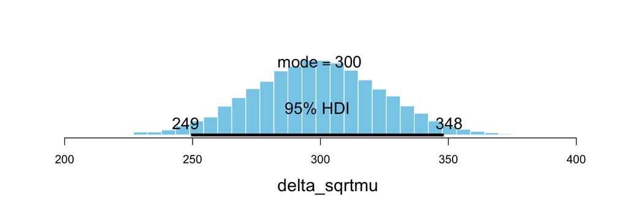

```r
plot_post(posterior(rats2_jags)$delta_sqrtmu, xlab = "delta_sqrtmu")
```

In this model we have strong evidence that the standard deviations (on the squared scale) and the means are different. The distributions of squared lifetimes appear much more normal than the untransformed lifetimes.

Let’s compare the HDIs for the difference in mean lifetimes for the two models:

```r
HDIs <-
  bind_rows(
    hdi(posterior(rats_jags), regex_pars = "delta_mu") %>%
      mutate(model = "model 1"),
    hdi(posterior(rats2_jags), regex_pars = "delta_sqrtmu") %>%
      mutate(model = "model 2")
  ) %>%
  select(model, matches("*"))  # get model to the first column
HDIs
```

```
##     model          par       lo       hi prob
## 1 model 1     delta_mu 232.5200 362.6606 0.95
## 2 model 2 delta_sqrtmu 249.4157 348.2196 0.95
```

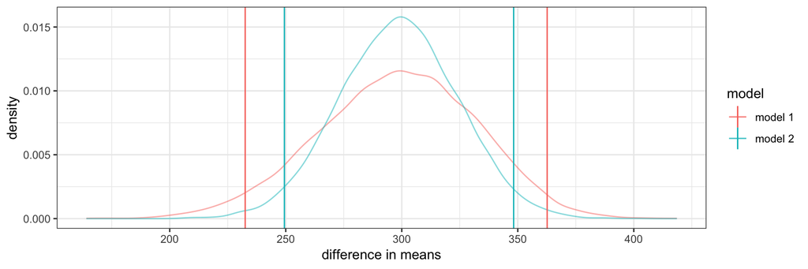

```r
gf_dens(~delta_mu, data = posterior(rats_jags), color = ~ "model 1") %>%
  gf_dens(~delta_sqrtmu, data = posterior(rats2_jags), color = ~ "model 2") %>%
  gf_vline(xintercept = ~lo, color = ~model, data = HDIs) %>%
  gf_vline(xintercept = ~hi, color = ~model, data = HDIs) %>%
  gf_labs(x = "difference in means", color = "model")
```

The centers of the posterior distributions are quite similar, but model 2 gives us a narrower HDI for the difference in the means.

4. In the previous problem, how do the priors for the difference in mean lifetimes compare? Sample from the prior to find out. Be sure to deal appropriately with the transformation so that you are doing an apples to apples comparison.

```r
rats_prior1 <-
  jags(
    model = metric_dich_model,
    parameters.to.save =
      c("mu", "sigma", "delta_mu", "sigma_ratio", "log10nu"),
    data = list(
      Nobs = 0,
      y = RatLives$DaysLive,
      g = as.numeric(factor(RatLives$Group)),
      mu_mean  = 700,
      mu_sd    = 300,
      sigma_lo = 60 / 1000,
      sigma_hi = 60 * 1000
    ),
    n.iter = 5000,
    n.burnin = 1000,
    n.chains = 2,
    DIC = FALSE
  )
rats_prior2 <-
  jags(
    model = metric_dich_model,
    parameters.to.save =
      c("mu", "sigma", "delta_mu", "sigma_ratio", "delta_sqrtmu", "log10nu"),
    data = list(
      Nobs = 0,
      y = RatLives$DaysLive^2,
      g = as.numeric(factor(RatLives$Group)),
      mu_mean  = 700^2 + 300^2,
      mu_sd    = (700^2 + 300^2) / 3,
      sigma_lo = 500 / 1000,
      sigma_hi = 500 * 1000
    ),
    n.iter = 5000,
    n.burnin = 1000,
    n.chains = 2,
    DIC = FALSE
  )
```

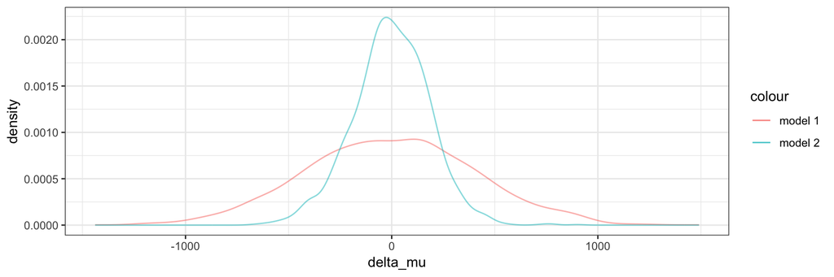

```r
gf_dens(~ delta_mu, data = posterior(rats_prior1), color = ~"model 1") %>%
gf_dens(~ delta_sqrtmu, data = posterior(rats_prior2), color = ~"model 2")
```

The prior for the difference in the mean lifetimes is a bit more spread out in the first model and less for the second model. If our goals was keep them similar, we should adjust one or the other. Despite this difference, both models agree that `delta_mu` is approximately 300. (Both priors consider 300 to be a plausible value, so it isn’t surprising that they agree in the posterior.)

5. Shohat-Ophir et al. (2012) were interested in alcohol preferences of sexually deprived male flies. The procedure is illustrated in Figure 16.13, and was described as follows:

   > One cohort, rejected-isolated, was subjected to courtship conditioning; they experienced 1-h sessions of sexual rejection by mated females, three times a day, for 4 days. …Flies in the mated-grouped cohort experienced 6-h sessions of mating with multiple receptive virgin females (ratio 1:5) for 4 days. Flies from each cohort were then tested in a two-choice preference assay, in which they voluntarily choose to consume food with or without 15% ethanol supplementation. (Shohat-Ophir et al., 2012, p. 1351, citations and figure reference removed)

   For each fly, the amount of each type of food consumed was converted to a preference ratio: the amount of ethanol-supplemented food minus the amount of regular food divided by the total of both. 3-day summary preference scores for each individual fruit fly were computed by summing the consumption of ethanol and non-ethanol across days 6–8. The amounts of food consumed and the preference ratios are in `CalvinBayes::ShohatOphirKAMH2012dataReduced`.
   1. How big are differences between groups relative to the uncertainty of the estimate? What do you conclude? (Answer this by computing what Kruschke calls the **effect size**. But note: effect size is not well defined; there are many things that go by that name. See, for example, the [Wikipedia article on effect size](https://en.wikipedia.org/wiki/Effect_size).)
   2. Instead of focusing on the relative amounts of ethanol and regular food consumed, we might also be interested in the absolute total amount of food consumed. Run the analysis on the total consumption data, which has column name `GrandTotal` in the data set. What do you conclude?

```r
flies_jags <-
  jags(
    model = metric_dich_model,
    parameters.to.save =
      c("mu", "sigma", "delta_mu", "sigma_ratio", "log10nu"),
    data = list(
      Nobs = nrow(ShohatOphirKAMH2012dataReduced),
      y = ShohatOphirKAMH2012dataReduced$PreferenceIndex,
      g = as.numeric(factor(ShohatOphirKAMH2012dataReduced$Group)),
      mu_mean  = 0,      # 0 = no preference
      mu_sd    = 0.5,    # range is (-1, 1), this will sample all of that range, but prefer near 0
      sigma_lo = 0.0001, # close to 0
      sigma_hi = 1       # 1 is max possible because values in (-1, 1)
    ),
    n.iter = 5000,
    n.burnin = 1000,
    n.chains = 2,
    DIC = FALSE
  )
```

(Omitting diagnositics to save space.)

Posterior distribution and HDI for `delta_mu` and effect size.

```r
flies_post <-
  posterior(flies_jags) %>%
  mutate(efsize = delta_mu / sqrt((sigma.1^2 + sigma.2^2) / 2))
gf_dens( ~ efsize, data = flies_post)
gf_dens( ~ delta_mu, data = flies_post)
hdi(flies_post, pars = c("efsize", "delta_mu"))
```

```
##        par         lo        hi prob
## 1 delta_mu 0.08399878 0.4945389 0.95
## 2   efsize 0.25500843 2.3855492 0.95
```

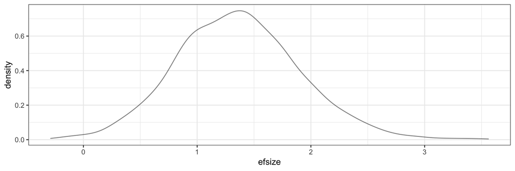

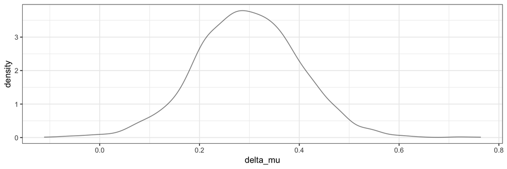

Conclusion:

- There appears to be a credible difference in preference (we would reject the hypothesis that there is no difference).
- The effect size is credibly bigger than 0.2 (a benchmark often used in pyschology to indicate a “big” effect).

```r
flies2_jags <-
  jags(
    model = metric_dich_model,
    parameters.to.save =
      c("mu", "sigma", "delta_mu", "sigma_ratio", "log10nu"),
    data = list(
      Nobs = nrow(ShohatOphirKAMH2012dataReduced),
      y = ShohatOphirKAMH2012dataReduced$GrandTotal,
      g = as.numeric(factor(ShohatOphirKAMH2012dataReduced$Group)),
      mu_mean  = 150,    # rough order of maginitude of amonts eaten
      mu_sd    = 100,    # very broad
      sigma_lo = 10 / 1000,
      sigma_hi = 10 * 1000
    ),
    n.iter = 5000,
    n.burnin = 1000,
    n.chains = 2,
    DIC = FALSE
  )
```

Posterior distribution and HDI for `delta_mu` and effect size.

```r
flies2_post <-
  posterior(flies2_jags) %>%
  mutate(efsize = delta_mu / sqrt((sigma.1^2 + sigma.2^2) / 2))
gf_dens( ~ efsize, data = flies2_post)
gf_dens( ~ delta_mu, data = flies2_post)
hdi(flies2_post, pars = c("efsize", "delta_mu"))
```

```
##        par          lo        hi prob
## 1 delta_mu -19.2292020 22.820278 0.95
## 2   efsize  -0.8284769  0.991917 0.95
```

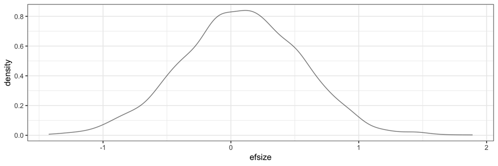

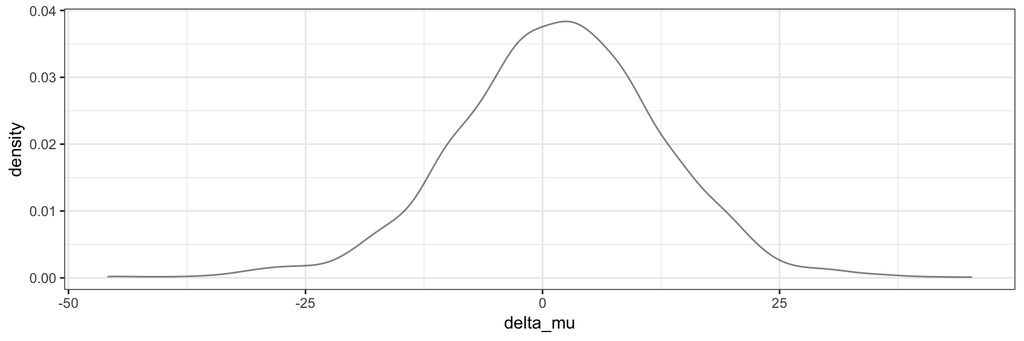

Conclusion:

- There is a lot of variability, but neither group clearly eats more than the other.
- Both large and small effect sizes are credible.
- We cannot attribute the preference difference in the previous part to differences in total consumption. (If there were a clear indication that one group consumed more, that could explain why the preference ratio was different from 0.)

## Chapter 17

1. Use Galton’s data on the men to estimate
   1. The average of height of men whose parents are 65 and 72 inches tall.
   2. The middle 50% of heights of men whose parents are 65 and 72 inches tall.

   You may use either JAGS or Stan.

```r
set.seed(54321)
library(dplyr)
GaltonM <-
  mosaicData::Galton %>%
  filter(sex == "M") %>%
  group_by(family) %>%
  sample_n(1) %>%
  mutate(midparent = (father + mother) / 2)
```

```r
galton_model <- function() {
  for (i in 1:length(y)) {
    y[i]   ~ dt(mu[i], 1/sigma^2, nu)
    mu[i] <- alpha0 + alpha1 * (x[i] - mean(x))
  }
  sigma ~ dunif(6/100, 6 * 100)
  nuMinusOne ~ dexp(1/29)
  nu <- nuMinusOne + 1
  alpha0 ~ dnorm(0, 1/100^2)   # 100 is order of magnitude of data
  alpha1 ~ dnorm(0, 1/4^2)     # expect roughly 1-1 slope
  beta1 <- alpha1
  beta0 <- alpha0 - mean(x) * alpha1
}
```

```r
library(R2jags)
library(mosaic)
galton_jags <-
  jags(
    model = galton_model,
    data = list(y = GaltonM$height, x = GaltonM$midparent),
    parameters.to.save = c("beta0", "beta1", "sigma", "nu"),
    n.iter   = 5000,
    n.burnin = 2000,
    n.chains = 4,
    n.thin   = 1
  )
```

```r
Post <-
  posterior(galton_jags) %>%
  mutate(
    avg_ht = beta0 + beta1 * 68.5,
    ind_ht = avg_ht + rstudent_t(12000, mean = 0, sigma = sigma, df = nu))

Post %>% hdi(0.95, pars = "avg_ht")
```

```
##      par       lo       hi prob
## 1 avg_ht 70.17743 71.15686 0.95
```

```r
Post %>% hdi(0.50, pars = "ind_ht")
```

```
##      par       lo       hi prob
## 1 ind_ht 69.20809 72.18985  0.5
```

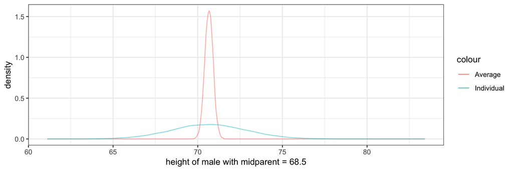

```r
gf_dens(~avg_ht, data = Post, color = ~ "Average") %>%
  gf_dens(~ind_ht, data = Post, color = ~ "Individual") %>%
  gf_labs(x = "height of male with midparent = 68.5")

# plot_post(Post$avg_ht, hdi_prob = 0.95, xlab = "average")
# plot_post(Post$ind_ht, hdi_prob = 0.50, xlab = "individual")
```

2. When centering, why did we center x but not y?

Centering on x was needed to break the correlation between the slope and intercept (which makes JAGS much more efficient). It can sometimes make the intercept easier to interpret as well.

Centering on y does not hurt anything, but the correlation has already been removed by centering on x, so centering y isn’t necessary. If we do center y, then our response essentially becomes how different is y from the average y in our data.

Note: We don’t need to center on the mean. Sometimes centering is done with convenient benchmark value. As long as the benchmark is near the mean of the values in our data, correlation will be greatly reduced. Said another way: we should pick a benchmark that is imidst the data – or design the study to collect data centered roughly on the benchmark value.